# Gráficos y su interprestación

```r
suppressMessages(library(readr))
suppressMessages(library(ggplot2))
suppressMessages(library(gridExtra))
suppressMessages(library(tidyverse))
suppressMessages(library(lazyeval))

dataset <- suppressMessages(read_csv("classification-results.csv"))
dataset[,8:ncol(dataset)] <- round(dataset[,8:ncol(dataset)],digits = 3)

stations <- unique(dataset$var)
algoritmos <- unique(dataset$alg)
metrics <- c("FAR","Sensitivity","Specificity","Accuracy","Kappa","F1","Precision")

#' ## Carga dataset
#' Creación de dataset genérico para resultados clasificación
df <- dataset %>%
  unite(dataset,
        col=label,c("dataset","var","config.train","config.vars","T","alg"),
        sep = "-",remove=FALSE) %>%
  select(label,dataset,var,config.train,config.vars,T,alg,FAR,Sensitivity,Specificity,Accuracy,Kappa,F1,Precision)
```

## Clasificación

Estaciones vs algoritmos: cuales de los algoritmos son “mejores” respecto a F1, Recall, precision

```r
df3 <-  df %>% filter( dataset == "dacc" & T==1 )
```

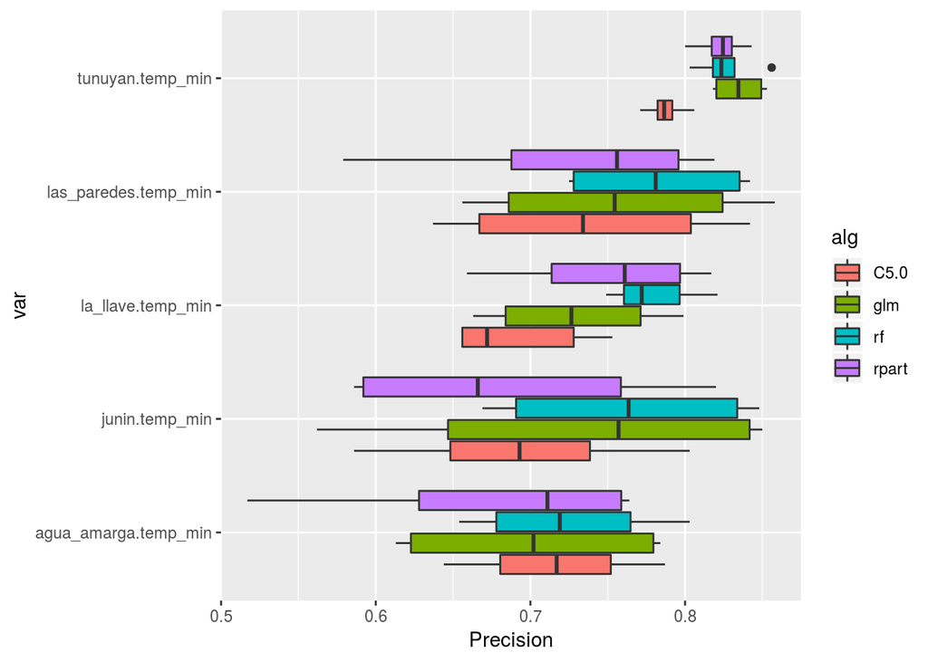

```r
p <-ggplot(aes(y = Precision , x = var, fill = alg), data = df3) + geom_boxplot() + coord_flip()
print(p)
```

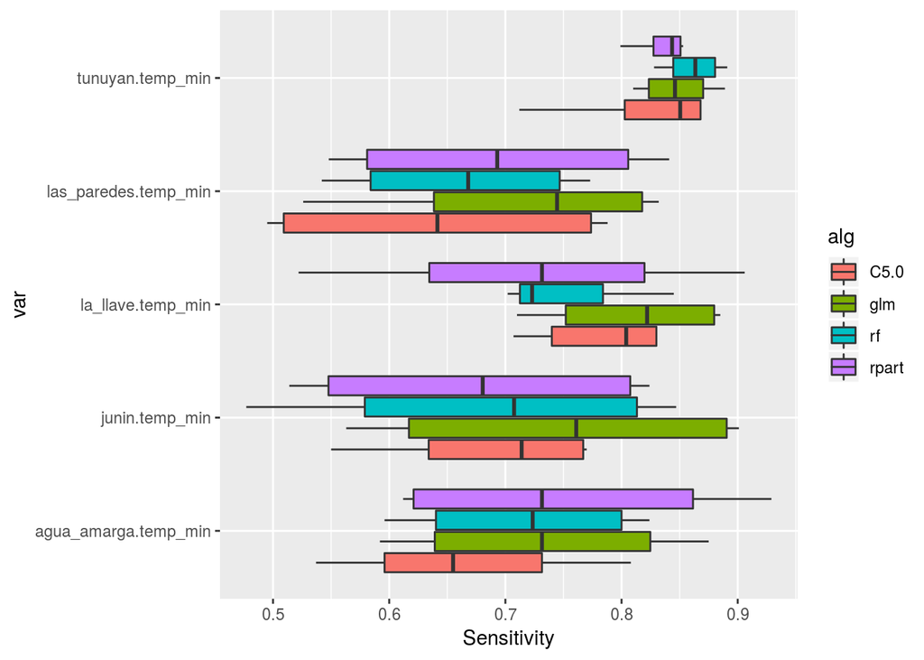

```r
p <-ggplot(aes(y = Sensitivity , x = var, fill = alg), data = df3) + geom_boxplot() + coord_flip()
print(p)
```

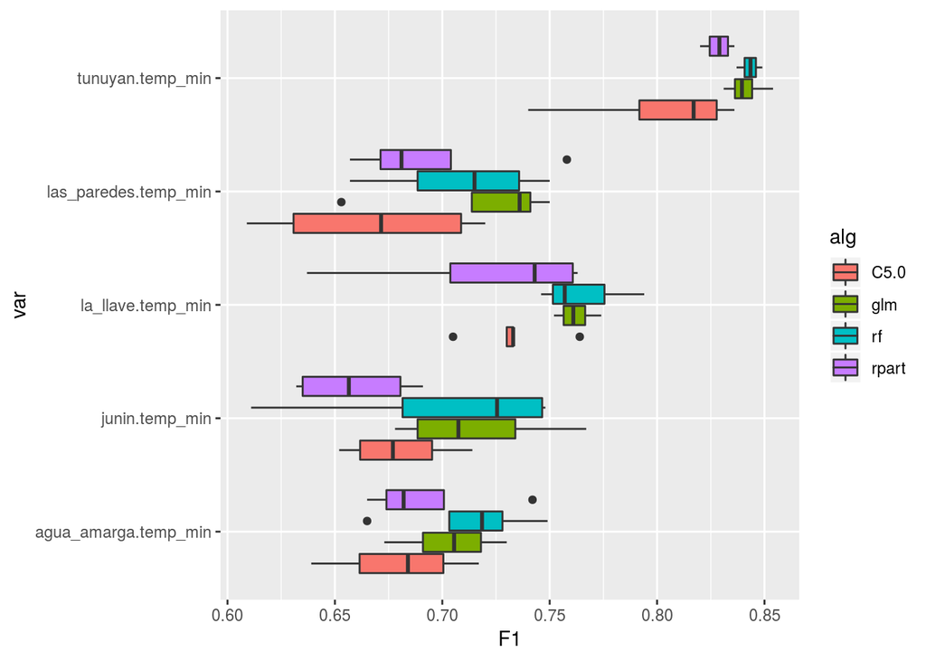

```r
#png("plot-estaciones-vs-algs-F1-filtro-datasetDacc-T1.png")
p <-ggplot(aes(y = F1 , x = var, fill = alg), data = df3) +
  geom_boxplot() + coord_flip() #+ labs(fill="T")

print(p)
```

```r
#dev.off()
```

Ahora, lo mismo que lo anterior pero considerando todos los T

```r
df3 <-  df %>% filter( dataset == "dacc" )
```

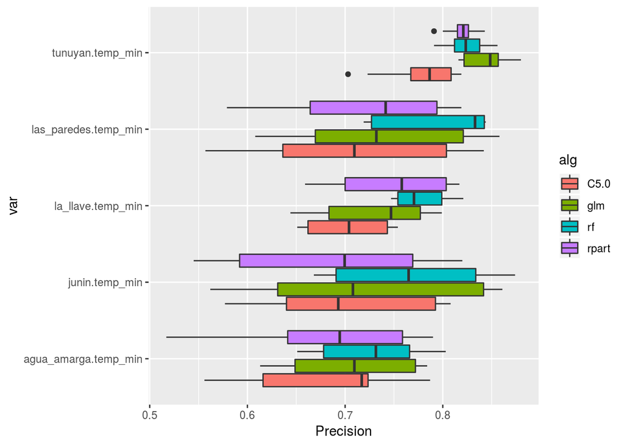

```r
p <-ggplot(aes(y = Precision , x = var, fill = alg), data = df3) + geom_boxplot() + coord_flip()
print(p)
```

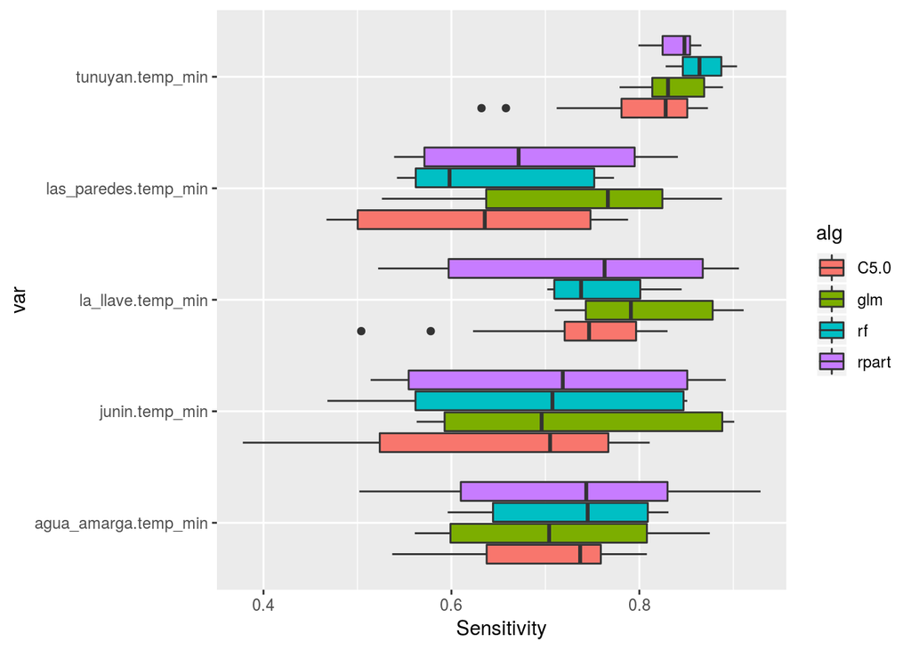

```r
p <-ggplot(aes(y = Sensitivity , x = var, fill = alg), data = df3) + geom_boxplot() + coord_flip()
print(p)
```

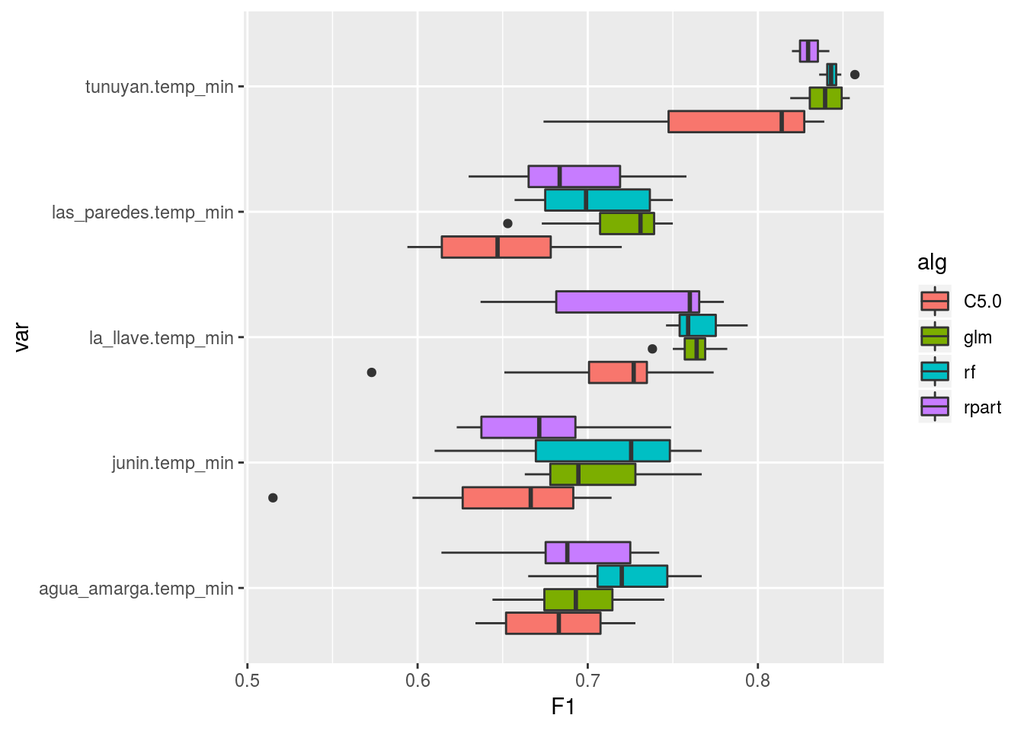

```r
#png("plot-estaciones-vs-algs-F1-filtro-datasetDacc-T1.png")
p <-ggplot(aes(y = F1 , x = var, fill = alg), data = df3) +
  geom_boxplot() + coord_flip() #+ labs(fill="T")

print(p)
```

```r
#dev.off()
```

RF por cada una de las estaciones

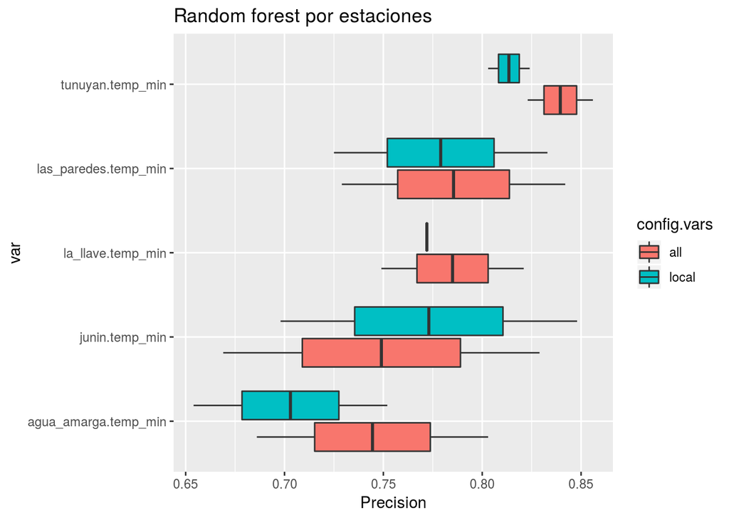

```r
df3 <-  df %>% filter( dataset == "dacc" & T==1 & alg=="rf")


p <-ggplot(aes(y = Precision , x = var, fill = config.vars), data = df3) + geom_boxplot() + coord_flip() + labs(title="Random forest por estaciones")
print(p)
```

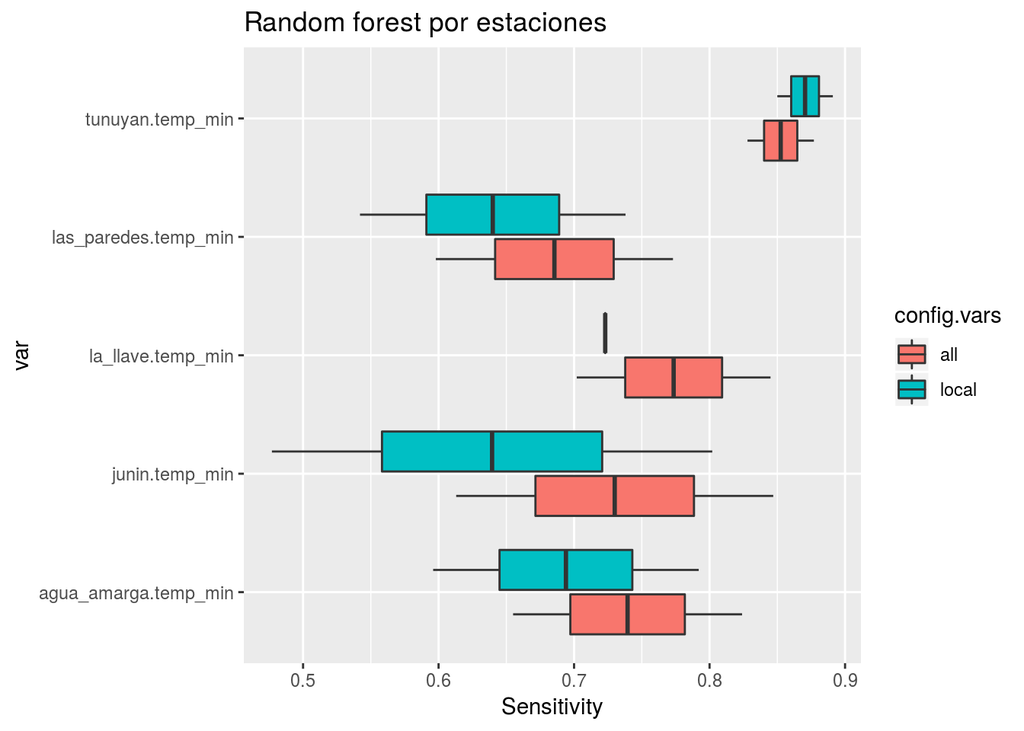

```r
p <-ggplot(aes(y = Sensitivity , x = var, fill = config.vars), data = df3) + geom_boxplot() + coord_flip() + labs(title="Random forest por estaciones")
print(p)
```

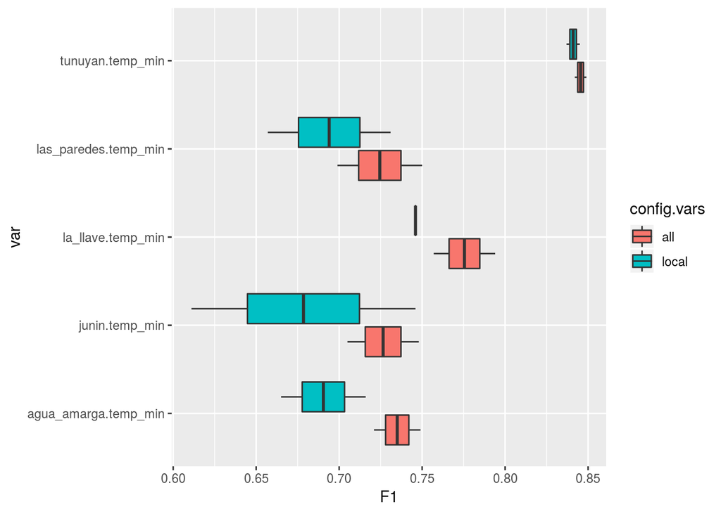

```r
p <-ggplot(aes(y = F1 , x = var, fill = config.vars), data = df3) +
  geom_boxplot() + coord_flip() #+ labs(fill="T")
print(p)
```

## GLM por cada una de las estaciones

[figure not shown]

```r
df3 <-  df %>% filter( dataset == "dacc" & T==1 & alg=="glm")

p <-ggplot(aes(y = Precision , x = var, fill = config.vars), data = df3) + geom_boxplot() + coord_flip() + labs(title="Random forest por estaciones")
print(p)
```

[figure not shown]

```r
p <-ggplot(aes(y = Sensitivity , x = var, fill = config.vars), data = df3) + geom_boxplot() + coord_flip() + labs(title="Random forest por estaciones")
print(p)
```

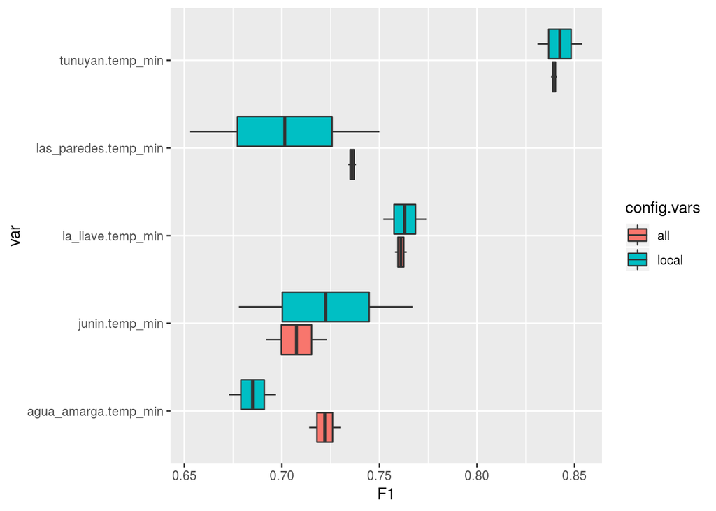

```r
p <-ggplot(aes(y = F1 , x = var, fill = config.vars), data = df3) +
  geom_boxplot() + coord_flip() #+ labs(fill="T")
print(p)
```

Comportamiento general de local vs all de los algoritmos por cada estación según métrica. Cada linea incluye casos T=1…4, normal/smote, all/local

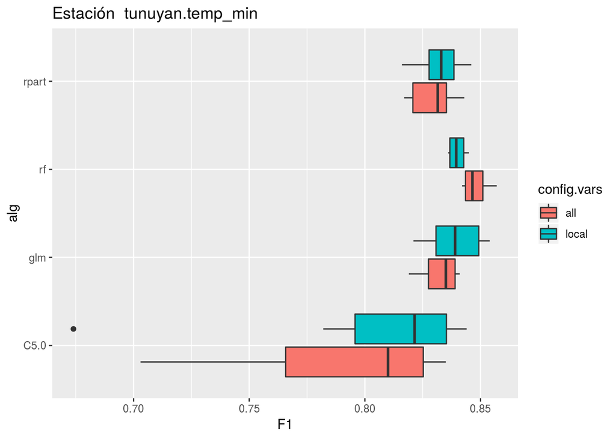

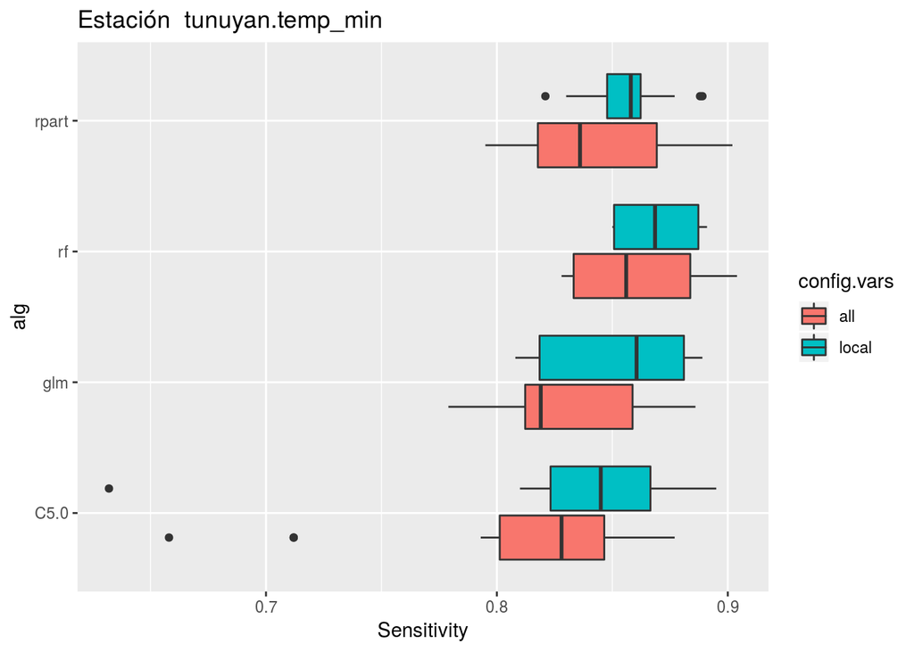

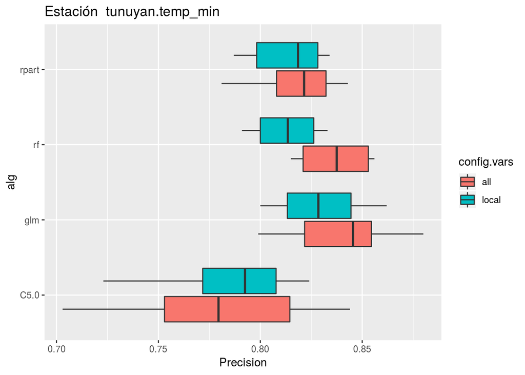

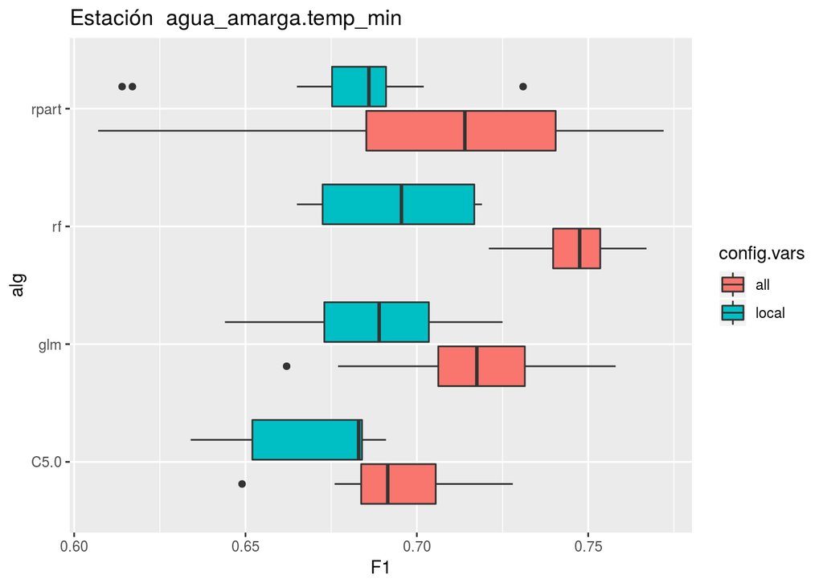

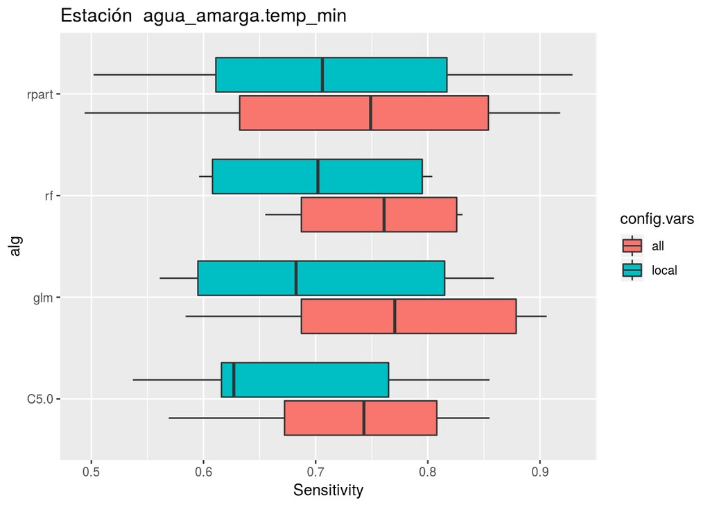

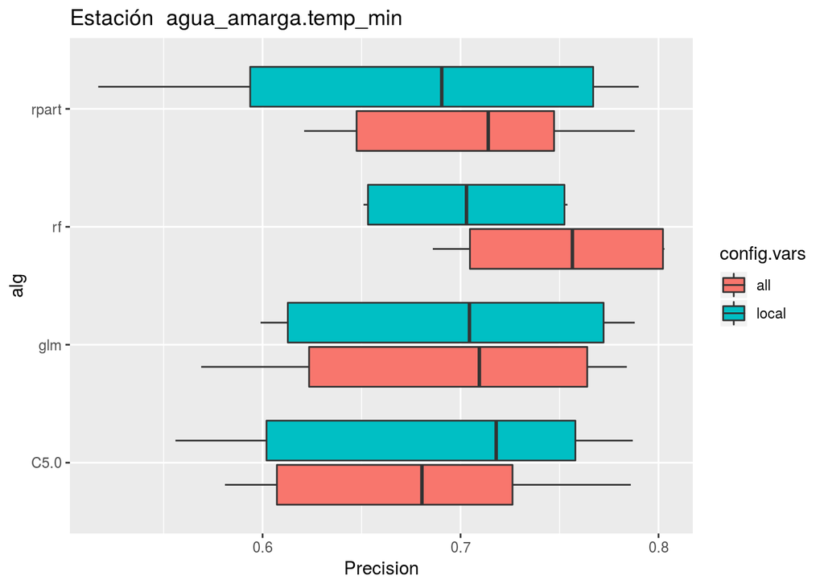

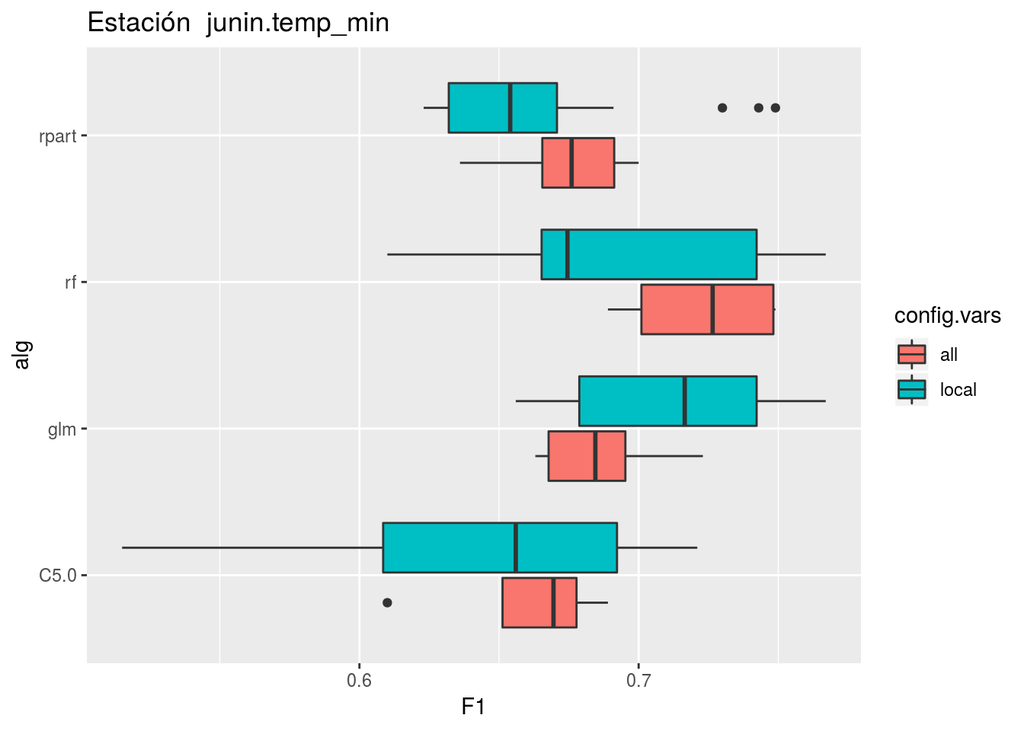

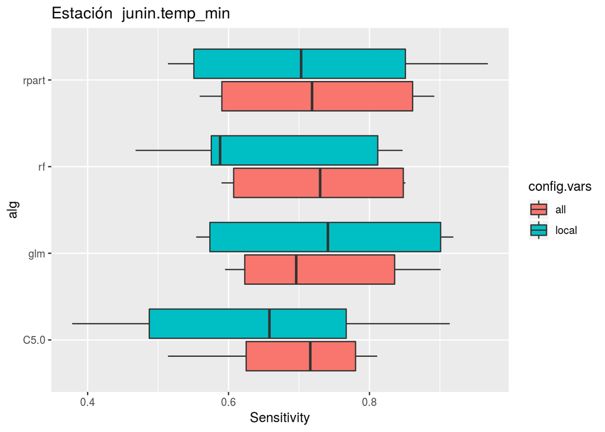

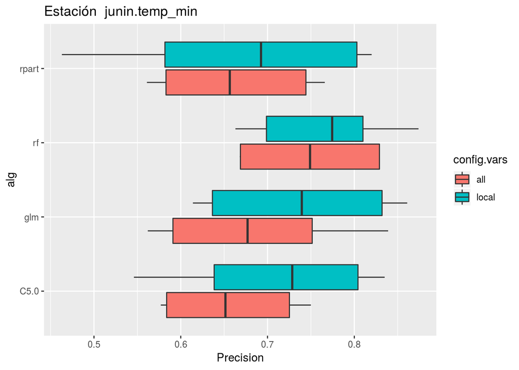

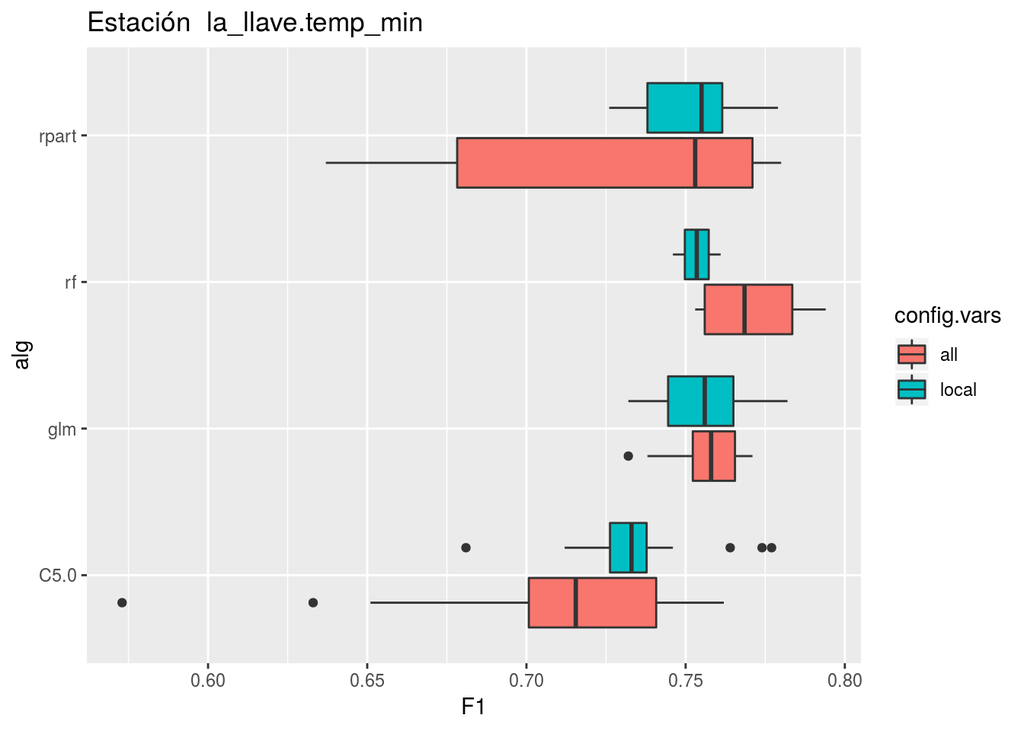

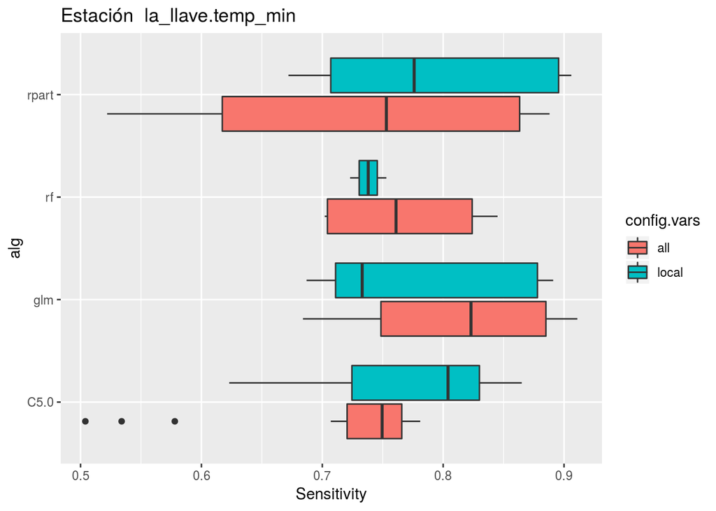

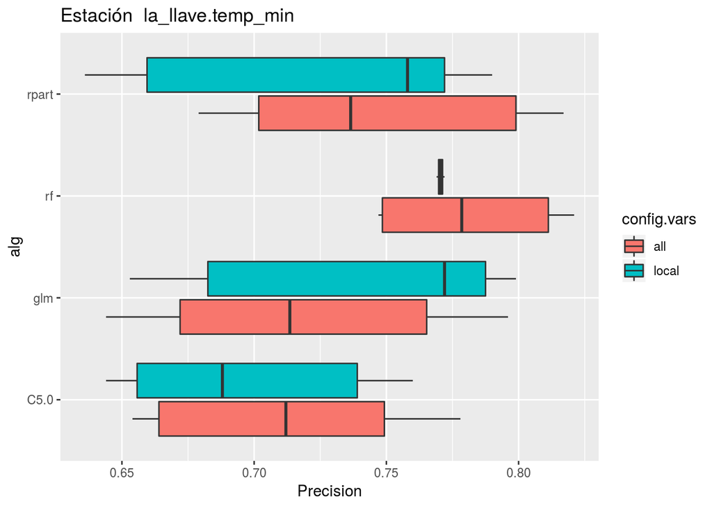

[3 more figures not shown]

```r
for(s in stations){

  df1 <- df %>% filter( var == s )

  p <-ggplot(aes(y = F1 , x = alg, fill = config.vars), data = df1) +
    geom_boxplot() + coord_flip() + labs(title=paste("Estación",s,sep="  "))
  print(p)
  p <-ggplot(aes(y = Sensitivity , x = alg, fill = config.vars), data = df1) +
    geom_boxplot() + coord_flip() + labs(title=paste("Estación",s,sep="  "))
  print(p)
  p <-ggplot(aes(y = Precision , x = alg, fill = config.vars), data = df1) +
    geom_boxplot() + coord_flip() + labs(title=paste("Estación",s,sep="  "))
  print(p)

}
```

```r
library(reshape)
```

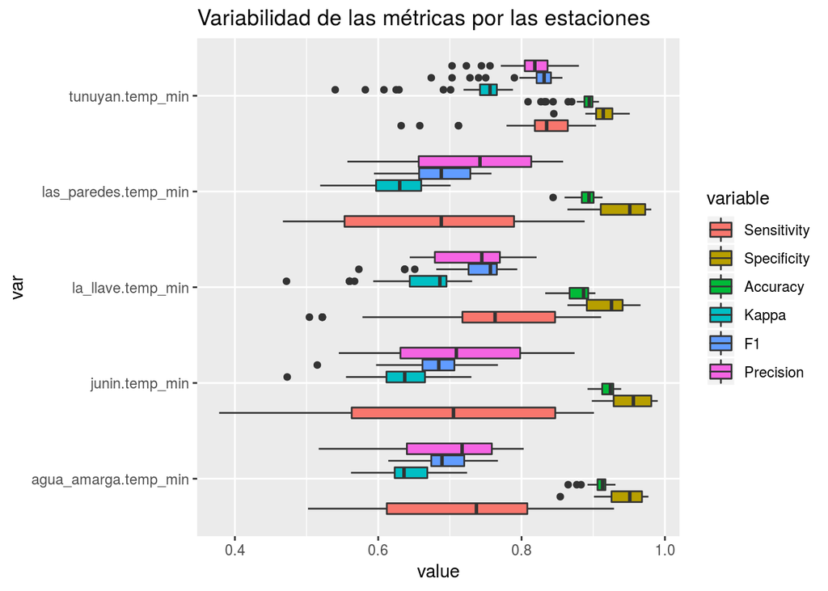

```r
df3 <-  df %>% filter( dataset == "dacc") %>% select(-one_of(c("FAR")))

#  melt(df3,id.vars="label")
df4 <- melt(as.data.frame(df3),
            id.vars =(c("label","dataset","var","config.train","config.vars","T","alg")),
            measure.vars = metrics[-1])

p <-ggplot(aes(y = value , x = var, fill = variable), data = df4) +
  geom_boxplot() + coord_flip() + labs(title="Variabilidad de las métricas por las estaciones")
print(p)
```

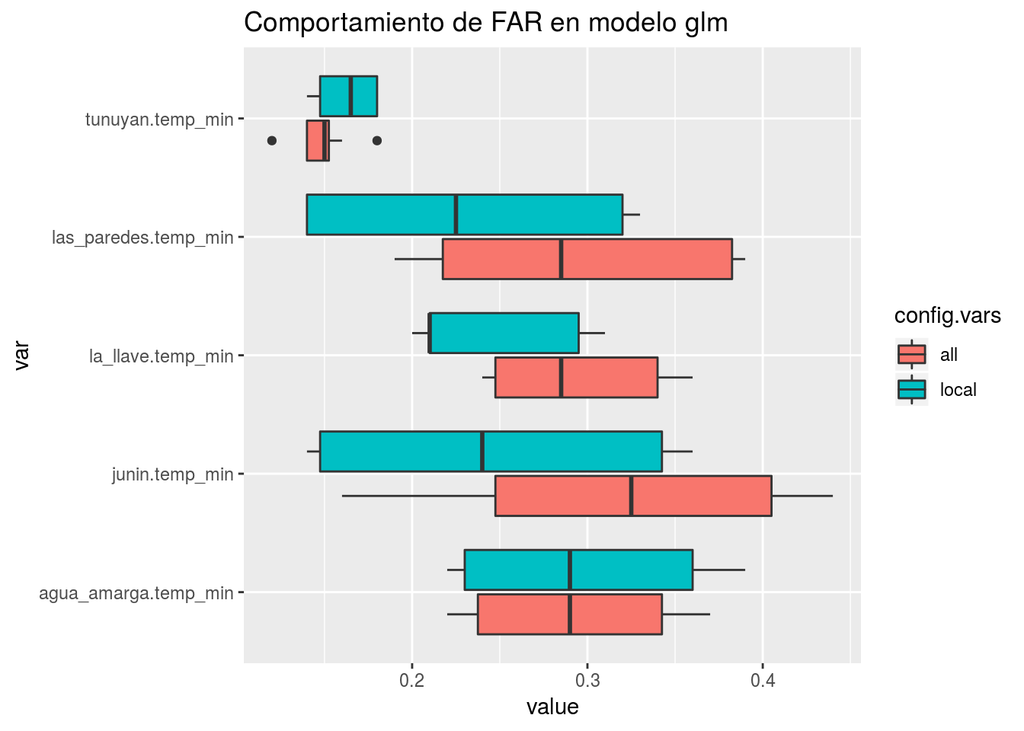

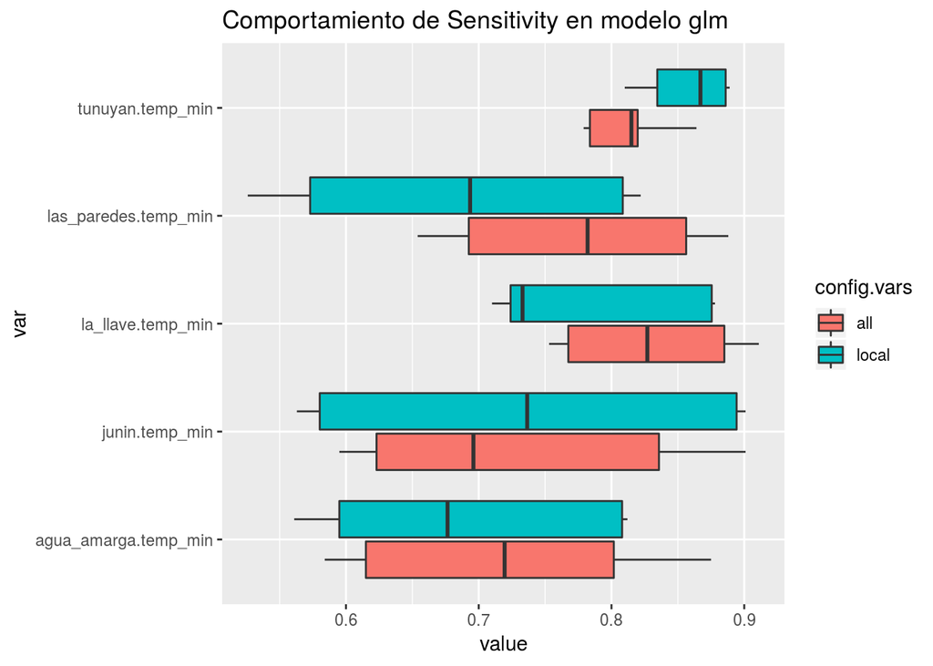

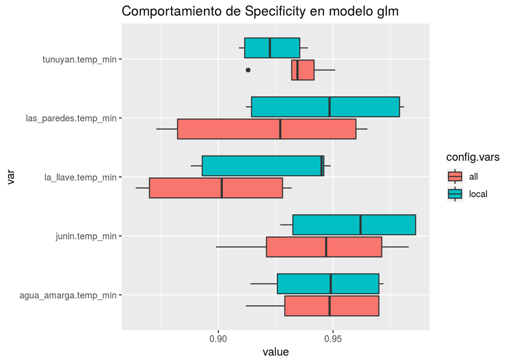

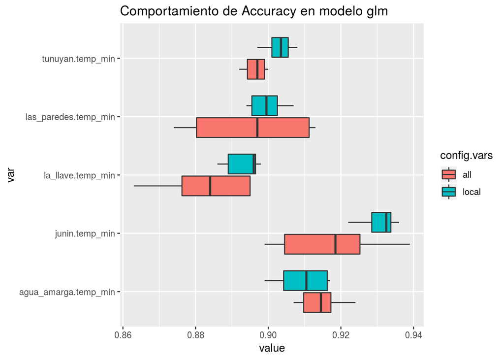

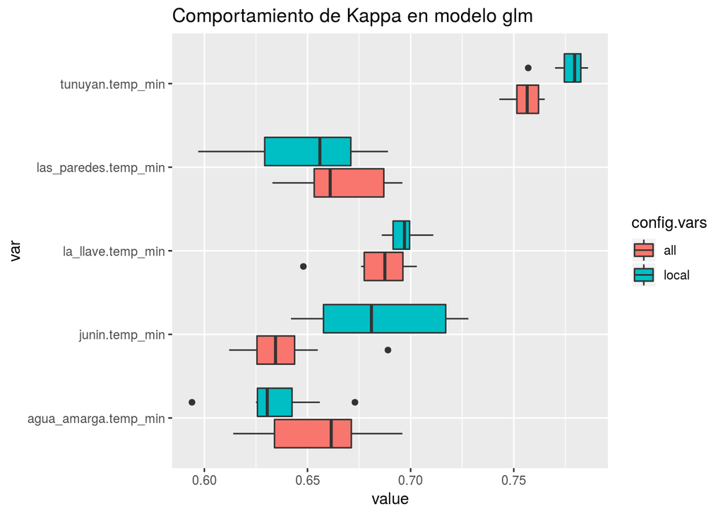

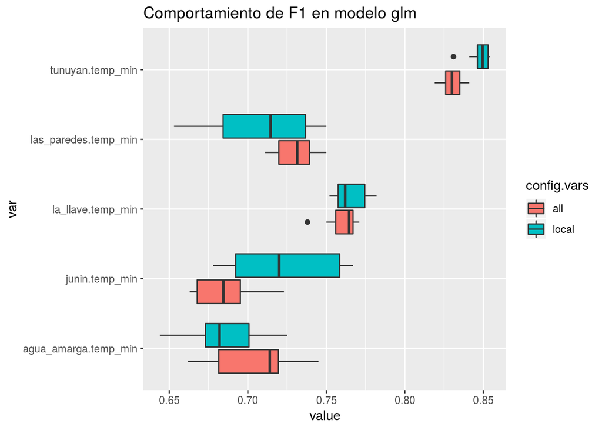

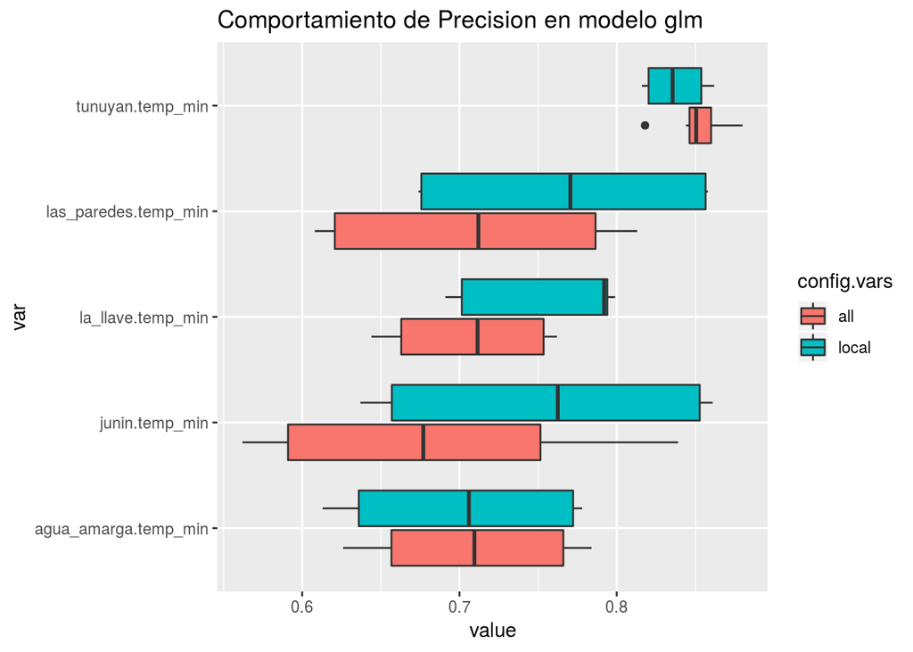

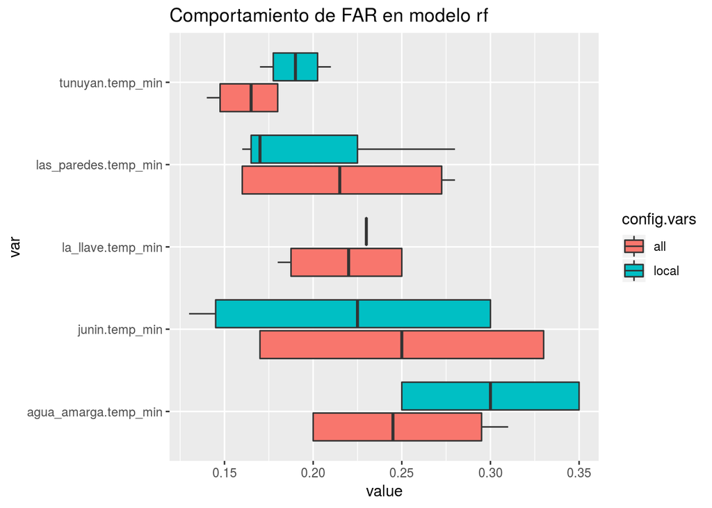

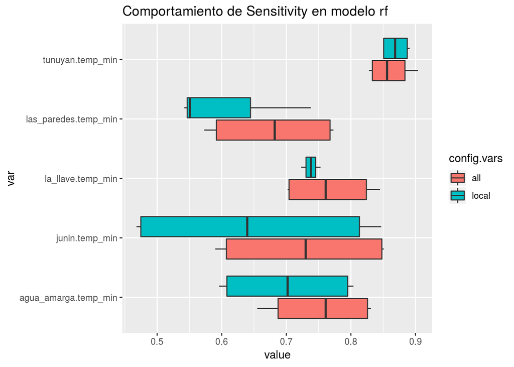

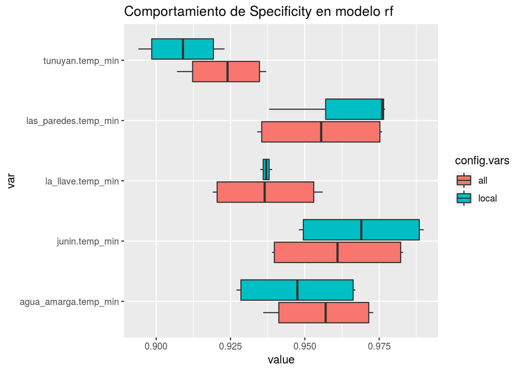

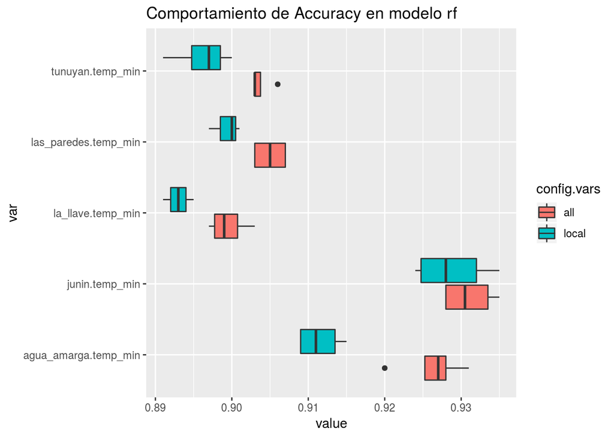

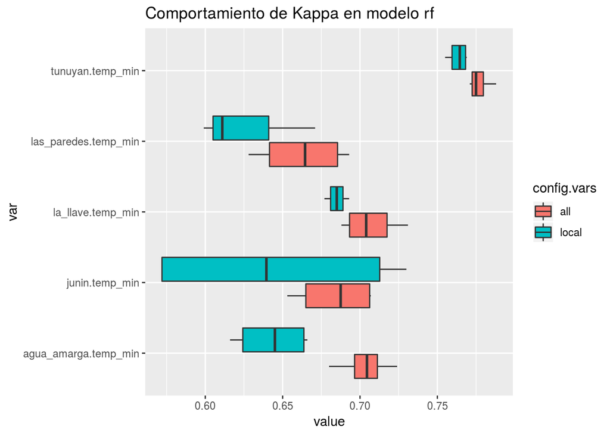

[16 more figures not shown]

```r
df4 <- df %>% filter( dataset == "dacc")
df4 <- melt(as.data.frame(df4),
            id.vars =(c("label","dataset","var","config.train","config.vars","T","alg")),
            measure.vars = metrics)

for(a in algoritmos)
{
  for(m in metrics)
  {
    df5 <- df4 %>% filter( alg == a & variable == m)
    p <-ggplot(aes(y = value , x = var, fill = config.vars), data = df5) +
      geom_boxplot() + coord_flip() + labs(title=paste("Comportamiento de ",m," en modelo ",a,sep=""))
    print(p)
  }
}
```

Random forest

- En agua amarga y Tunuyan, el FAR es menor en modelos config all. También para estas estaciones config all tiene mayores valores de specificity y precision que config local, lo contrario para las restantes. Lo contrario para el resto de las estaciones (gana local)
- Los mejores modelos en terminos de sensitivity/recall son config all
- Valores de accuracy entre (aproximado) 0.89 y 0.94
- Valor de Kappa aumenta (hay mayores valores) con config all, analizando las medias

Comparación normal vs smote por estación para métricas sensitivity y precision

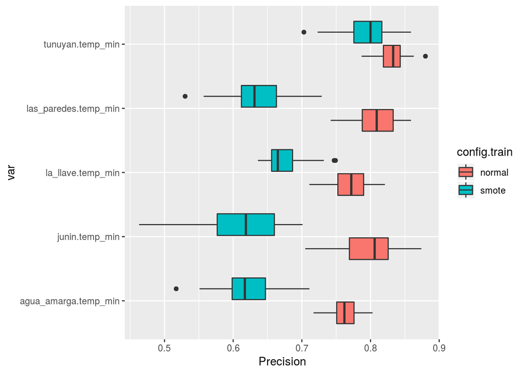

```r
p <-ggplot(aes(y = Precision , x = var, fill = config.train), data = df) + geom_boxplot() + coord_flip()
print(p)
```

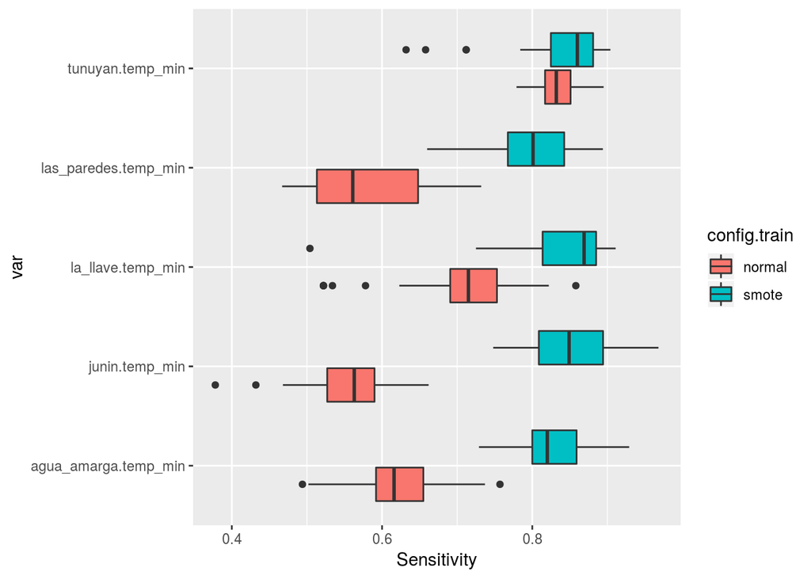

```r
p <-ggplot(aes(y = Sensitivity , x = var, fill = config.train), data = df) + geom_boxplot() + coord_flip()
print(p)
```

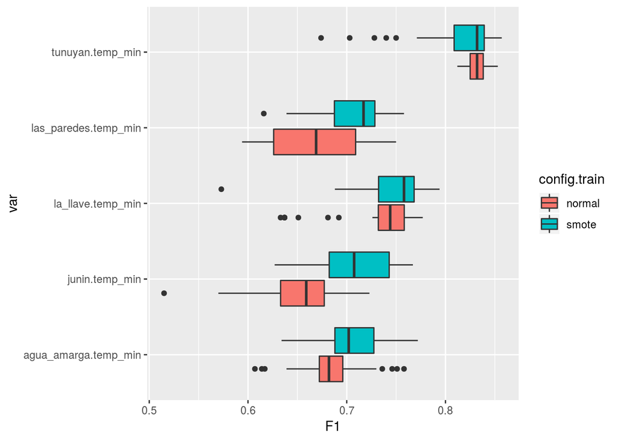

```r
p <-ggplot(aes(y = F1 , x = var, fill = config.train), data = df) + geom_boxplot() + coord_flip()
print(p)
```

La configuración SMoTE aumenta la sensitivity/F1 en detrimento de la precision. Es una consecuencia esperable.